# Stochastic distributions: EMD chapter 4

(adapted from a lab by Jacqui Frair & John Stella, which was adapted from one by Jesse Brunner and from material produced by Ben Bolker)

Our goals in this lab are to:

1. get a feel for a suite of important *stochastic* distributions, seeing how their parameters changer their shapes and behavior
2. understand the processes that might produce some of these distributions
3. create reference figures that you can refer to when using these distributions

## Distribution Functions

R knows about lots of probability distributions. For each, it can generate random numbers drawn from the distribution ('deviates'); compute the cumulative distribution function and the probability distribution function; and compute the quantile function, which gives the x value such that \( \int_0^x \! P(x) \, \mathrm{d} x \) (area under the curve from \( 0 \) to \( x \)) is a specified value, such as 0.95. (Think about “tail areas” from standard statistics.)

The figure below shows for an arbitrary distribution the R commands showing the density function (`ddist()`), cumulative distribution function (`pdist()`), quantile function (`qdist()`), and random‐deviate function (`rdist()`) where “`dist`” is the name of the distibutions (e.g., `binom`, `norm`, `pois`, `chi`, etc.).

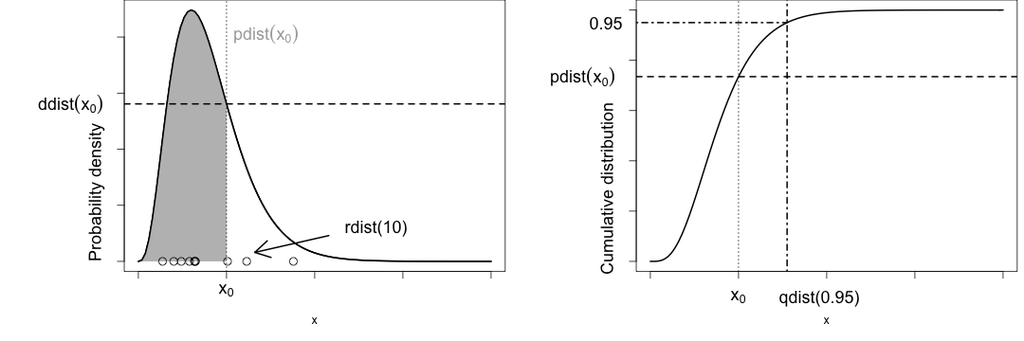

To illustrate how we can use these functions, let's consider the Binomial distribution, with which you are probably familiar. It is essentially a coin-flip where one outcome, say heads, is “success” or an “event.”

`rbinom(n, size, p)` gives `n` random samples each with `size` binomial trials (= coin flips) per sample, and `p` probability of success in each trial. For example, to simulate an experiment where 10 people (10 samples) each flip a coin 8 times (= 8 trials) with a fair coin (probability of success [1] is 0.5) we would use the following command:

```r
rbinom(n = 10, size = 8, p = 0.5)
```

```
##  [1] 3 6 3 4 6 7 4 3 2 2
```

A simulation of 200 values from a binomial distribution with `size` = 12 (12 binary trials) and `p` = 0.15 per trial would look like this:

```
## stat_bin: binwidth defaulted to range/30. Use 'binwidth = x' to adjust
## this.
```

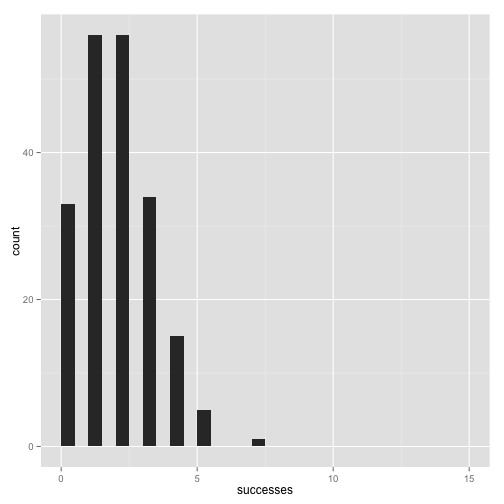

```r
successes <- rbinom(n = 200, size = 12, p = 0.15)

library(ggplot2)
qplot(successes, xlim = c(0, 15))
```

`dbinom(x,size,p)` gives the value of the probability distribution function (pdf) for any given value of \( x \). Since the binomial is discrete, \( x \) has to be an integer, and the pdf is just the probability of getting that many successes; if you try dbinom with a non-‐integer x, you’ll get a zero and a warning. (Note: For a continuous distribution the analog is the probability *density* function, which calculates the probability density within some range \( [a, b] \)).

```r
dbinom(x = 2, size = 15, prob = 0.15)  # This is the probability of exactly 2 successes out of 15 trials, with a 15% chance of sucess on each trial
```

```
## [1] 0.2856
```

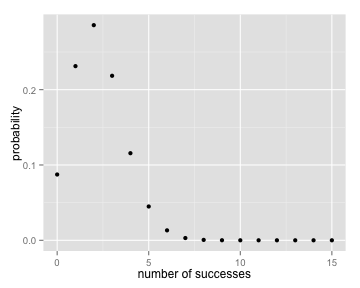

```r
x <- 0:15
qplot(x, y = dbinom(x, size = 15, prob = 0.15), xlab = "number of successes",
    ylab = "probability")
```

[figure not shown]

```r
qplot(x, ymax = dbinom(x, size = 15, prob = 0.15), ymin = 0, geom = "linerange",
    , xlab = "successes", ylab = "cummulative probability")
```

These plots show the probability of getting \( x \) successes given 15 trials and a probability of 0.15. Notice that they sum to 1.

`pbinom(q, size, p)` gives the value of the *cumulative* distribution function (cdf) at `q`. That is, it gives the probability of getting `q` or fewer successes. (This should sound sort of familiar. It is close to the definition of the p-value, only in that case we are interested in the probability of `q` *or more* successes, which is generally `1 - pbinom()`.) For example:

```r
pbinom(q = 2, size = 15, prob = 0.15)  # The probability of get 2 or fewer successes (i.e., 0, 1, or 2)
```

```
## [1] 0.6042
```

```r
sum(dbinom(x = 0:2, size = 15, prob = 0.15))  # We can get the same result by summing up the probabilities of getting 0, 1, and 2 successes
```

```
## [1] 0.6042
```

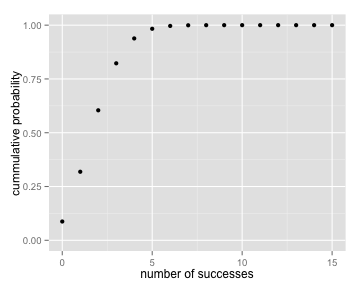

```r
qplot(x, y = pbinom(q = x, size = 15, prob = 0.15), ylim = c(0, 1), xlab = "number of successes",
    ylab = "cummulative probability")
```

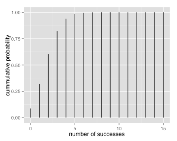

```r
qplot(x, ymax = pbinom(q = x, size = 15, prob = 0.15), ymin = 0, geom = "linerange",
    ylim = c(0, 1), xlab = "number of successes", ylab = "cummulative probability")
```

These plots then show the cummulative probability of getting \( x \) or fewer successes. See that they quickly converge on 1.

```r
qbinom(p = 0.95, size = 15, prob = 0.15)  # There is a 95% probability that in 15 trials, each with 0.15 chance of success, there will be this many or fewer successe
```

```
## [1] 5
```

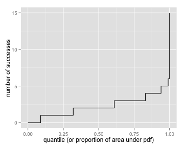

```r
qplot(x = c(0, 1), stat = "function", fun = qbinom, args = list(size = 15, prob = 0.15),
    geom = "step", xlab = "quantile (or proportion of area under pdf)", ylab = "number of successes")
```

Notice that because the binomial deals with discrete outcomes, there are a range of cummulative probabilities associated with each number outcomes (i.e., it is a jagged curve).

These four functions exist for each of the distributions R has built in: e.g., for the normal distribution they are `rnorm()`, `pnorm()`, `dnorm()`,and `qnorm()`. Each distribution has its own set of parameters as appropriate. For example, `pnorm(x, mean, sd)`. Use `?rnorm` for more information.

## Plotting discrete stochastic distributions

Once again, it is useful to create a visual reference for these functions, particularly the pdfs (`dbinom()`), showing how parameter values alter the shape and look of the distributions. We can use the `stat_function` approach we used in the previous lab to plot discrete distributions. We need only specify “`n`,” the number of points to evaluate the function along. (Think about why that is.)

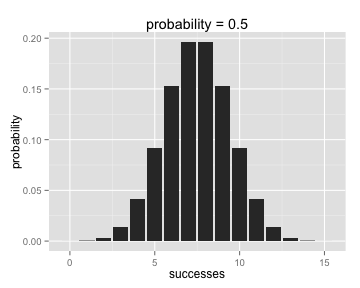

```r
qplot(x = 0:15, n = length(x), stat = "function", fun = dbinom, args = list(size = 15,
    prob = 0.5), xlab = "successes", ylab = "probability", main = "probability = 0.5")
```

Or we can generate the data in a data frame, and then plot it. We will take this approach because a) it is worth learning how to do so and b) it make creating a faceted or overlayed plot much simpler. So let's see how to generate the probabilities of success (pdfs) for probability of success = 0.1, 0.3, and 0.5 with 5, 15, and 50 trials. We will make use of the `expand.grid()` function, which is designed for this very purpose. It creates a data frame with all combinations of each vector we give it.

```r
df.5 <- expand.grid(x = c(0:5), trials = 5, prob = c(0.1, 0.3, 0.5))
df.5  # see how it is structured?
```

```
##    x trials prob
## 1  0      5  0.1
## 2  1      5  0.1
## 3  2      5  0.1
## 4  3      5  0.1
## 5  4      5  0.1
## 6  5      5  0.1
## 7  0      5  0.3
## 8  1      5  0.3
## 9  2      5  0.3
## 10 3      5  0.3
## 11 4      5  0.3
## 12 5      5  0.3
## 13 0      5  0.5
## 14 1      5  0.5
## 15 2      5  0.5
## 16 3      5  0.5
## 17 4      5  0.5
## 18 5      5  0.5
```

See how this works? OK. So we've created one data frame for five trials. Now let's create them for 15 and 50 trials and then combine them all together.

```r
df.15 <- expand.grid(x = c(0:15), trials = 15, prob = c(0.1, 0.3, 0.5))
df.50 <- expand.grid(x = c(0:50), trials = 50, prob = c(0.1, 0.3, 0.5))
# Now, to combine them all
df <- rbind(df.5, df.15, df.50)
```

Of course we could have done this in a single command:

```r
df <- rbind(expand.grid(x = c(0:5), trials = 5, prob = c(0.1, 0.3, 0.5)), expand.grid(x = c(0:15),
    trials = 15, prob = c(0.1, 0.3, 0.5)), expand.grid(x = c(0:50), trials = 50,
    prob = c(0.1, 0.3, 0.5)))
```

Anyway, we now have a data frame, `df`, with every combination of `x` and `prob`, along with labels for the number of `trials`. We still need to calculate the y-values, the probability of each outcome (`x` success) given the probability of success (`prob`), but this is pretty straightforward. We simply need to supply the right values of size and prob t the `dbinom()` function:

```r
df$y <- with(df, dbinom(x, size = trials, prob = prob))
```

It is then simple to plot this with different facets for each combination of parameters (9 facets, right?).

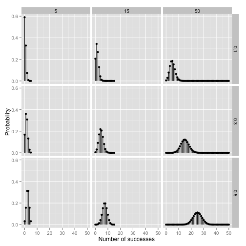

```r
ggplot(data = df, aes(x = x, y = y, ymax = y, ymin = 0)) + geom_point() + geom_linerange() +
    facet_grid(facets = prob ~ trials) + labs(x = "Number of successes", y = "Probability ")
```

But wait! We have the same x-limits on each column, even though the maximum number of successes varies. We can let the x-axis be “free” to allow different limits and create a prettier, more honest figure.

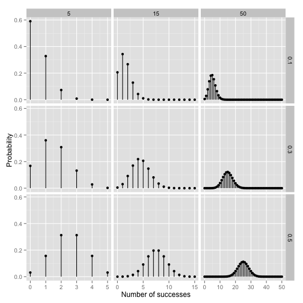

```r
ggplot(data = df, aes(x = x, y = y, ymax = y, ymin = 0)) + geom_point() + geom_linerange() +
    facet_grid(facets = prob ~ trials, scales = "free_x") + labs(x = "Number of successes",
    y = "Probability ")
```

We could also allow the y-axis to be free with `scales="free_xy"` or `scales="free_y"`.

## Homework: More functions to explore

Using the same basic tools, you should play with and create similar visual guides for the several other stochastic distributions. These include the other discrete distributions:

| Distribution | R function |
| --- | --- |
| Poisson | `dpois(x, lambda)` |
| negative binomial | `dnbinom(x, size, prob, mu)` |

And the continuous distributions:

| Distribution | R function |
| --- | --- |
| normal | `dnorm(x, mean, sd)` |
| log normal | `dlnorm(x, meanlog, sdlog)` |
| Gamma | `dgamma(x, shape, rate, scale)` # scale = 1/rate |
| beta | `dbeta(x, shape1, shape2)` |